# Final Project part 2

FTayari

March 11, 2018

In this report I used the data from accelerometers on the belt, forearm, arm, and dumbell of 6 participants to build models for making predictions on the train set and then appling the model to the test set for predicting the manner that participants did the exercise.

Note: I experiences memory usage error. so, I needed to split the mark down file into two sections: - Part 1: Tree, Pruning the tree with cross validation, and bagging - part 2:Random forests, Boosting, LDA, QDA,

```r
library(caret)
library(party)
library (tree)

training<-read.csv("pml-training.csv")
testing<-read.csv("pml-testing.csv")
```

# Cleaning the data and removing the unnecessary data

Droppng the summary statistics variables that include: “kurtosis_”, “skewness_”, “max_”, “min_”, “amplitude_”, “var_”, “avg_”, and “stddev_”

```r
training<-training[,c(8:11,37:49,60:68,84:86,116:124,151:160)]
testing<-testing[,c(8:11,37:49,60:68,84:86,116:124,151:160)]
```

# Random forests

```r
#mod.rf <- train(classe ~ .,method="rf",data=training)
library (randomForest)
mod.rf =randomForest(classe~.,data=training , importance =TRUE)


#Train set prediction
pred.train<-predict(mod.rf, training)
train.table<-table(predict=pred.train,truth = training$classe )
train.table
```

```
##        truth
## predict    A    B    C    D    E
##       A 5580    0    0    0    0
##       B    0 3797    0    0    0
##       C    0    0 3422    0    0
##       D    0    0    0 3216    0
##       E    0    0    0    0 3607
```

```r
(train.table[1,1]+train.table[2,2]+train.table[3,3]+train.table[4,4]+train.table[5,5])/sum(train.table)
```

```
## [1] 1
```

```r
# Test set prediction
pred.test<-predict(mod.rf, testing)
pred.test
```

```
##  1  2  3  4  5  6  7  8  9 10 11 12 13 14 15 16 17 18 19 20
##  B  A  B  A  A  E  D  B  A  A  B  C  B  A  E  E  A  B  B  B
## Levels: A B C D E
```

I used the random forrest in the randomForest package. It seems to be faster and gives 100% accuracy.

### Random forests with parallel method

```r
#library(parallel)
#library(doParallel)
#cluster <- makeCluster(detectCores() - 1)
#registerDoParallel(cluster)
#fitControl <- trainControl(method = "cv",number = 5, allowParallel = TRUE)

#mod.rf2 <- train(classe ~ .,method="rf",data=training,trControl = fitControl)
#stopCluster(cluster)
#registerDoSEQ()

#Train set prediction
#pred.train<-predict(mod.rf2, training)
#train.table<-table(predict=pred.train,truth = training$classe )
#train.table
#(train.table[1,1]+train.table[2,2]+train.table[3,3]+train.table[4,4]+train.table[5,5])/sum(train.table)

# Test set prediction
#pred.test<-predict(mod.rf2, testing)
#pred.test
```

# Boosting

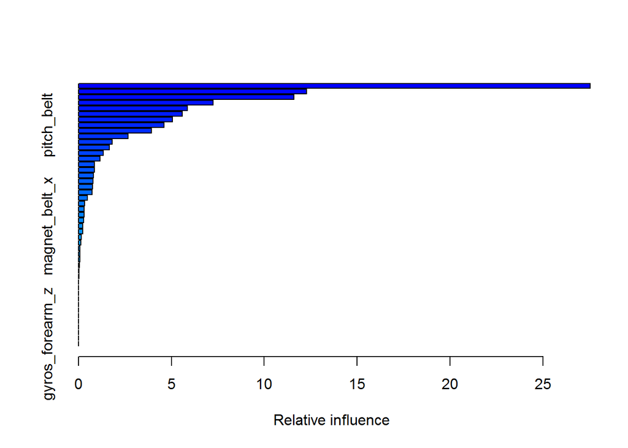

```
##                                 var      rel.inf
## roll_belt                 roll_belt 2.754644e+01
## pitch_forearm         pitch_forearm 1.227908e+01
## roll_forearm           roll_forearm 1.160126e+01
## magnet_dumbbell_z magnet_dumbbell_z 7.254982e+00
## magnet_belt_y         magnet_belt_y 5.868053e+00
## magnet_arm_x           magnet_arm_x 5.596872e+00
## yaw_belt                   yaw_belt 5.070016e+00
## pitch_belt               pitch_belt 4.602124e+00
## gyros_belt_z           gyros_belt_z 3.918293e+00
## magnet_forearm_z   magnet_forearm_z 2.671304e+00
## accel_forearm_x     accel_forearm_x 1.807760e+00
## roll_arm                   roll_arm 1.659732e+00
## magnet_belt_z         magnet_belt_z 1.341667e+00
## roll_dumbbell         roll_dumbbell 1.170995e+00
## accel_dumbbell_z   accel_dumbbell_z 8.701969e-01
## yaw_arm                     yaw_arm 8.657704e-01
## accel_belt_z           accel_belt_z 8.028899e-01
## magnet_forearm_x   magnet_forearm_x 7.771128e-01
## yaw_dumbbell           yaw_dumbbell 7.680294e-01
## accel_forearm_z     accel_forearm_z 7.267153e-01
## accel_arm_z             accel_arm_z 4.752494e-01
## accel_dumbbell_y   accel_dumbbell_y 3.350907e-01
## magnet_dumbbell_x magnet_dumbbell_x 3.095474e-01
## pitch_dumbbell       pitch_dumbbell 2.959299e-01
## magnet_dumbbell_y magnet_dumbbell_y 2.752812e-01
## magnet_belt_x         magnet_belt_x 2.313803e-01
## total_accel_arm     total_accel_arm 2.184400e-01
## magnet_arm_z           magnet_arm_z 1.482715e-01
## yaw_forearm             yaw_forearm 1.355313e-01
## pitch_arm                 pitch_arm 8.948061e-02
## gyros_belt_y           gyros_belt_y 8.929735e-02
## magnet_arm_y           magnet_arm_y 6.900889e-02
## total_accel_belt   total_accel_belt 4.352413e-02
## accel_dumbbell_x   accel_dumbbell_x 3.847433e-02
## magnet_forearm_y   magnet_forearm_y 2.579026e-02
## accel_forearm_y     accel_forearm_y 1.080033e-02
## accel_belt_y           accel_belt_y 4.164801e-03
## gyros_forearm_x     gyros_forearm_x 2.477110e-03
## gyros_arm_y             gyros_arm_y 2.087027e-03
## gyros_forearm_y     gyros_forearm_y 8.771161e-04
## gyros_belt_x           gyros_belt_x 0.000000e+00
## accel_belt_x           accel_belt_x 0.000000e+00
## gyros_arm_x             gyros_arm_x 0.000000e+00
## gyros_arm_z             gyros_arm_z 0.000000e+00
## accel_arm_x             accel_arm_x 0.000000e+00
## accel_arm_y             accel_arm_y 0.000000e+00
## gyros_forearm_z     gyros_forearm_z 0.000000e+00
```

```r
library (gbm)
#mod.boost <- train(classe ~ .,method="gbm",data=training)
mod.boost <- gbm(classe ~ .,data=training, distribution=
                         "gaussian",n.trees =5000 , interaction.depth =4)
summary (mod.boost)
```

As we can see boosting shows the most important parameters and results show that roll_belt is the most important one.

# LDA

```r
library (MASS)
mod.lda=lda(classe~. ,data=training)
pred.train<-predict(mod.lda , training)
train.table<-table(predict=pred.train$class,truth = training$classe )
train.table
```

```
##        truth
## predict    A    B    C    D    E
##       A 4501  577  357  214  160
##       B  171 2413  350  146  636
##       C  418  454 2240  350  330
##       D  442  158  402 2353  393
##       E   48  195   73  153 2088
```

```r
(train.table[1,1]+train.table[2,2]+train.table[3,3]+train.table[4,4]+train.table[5,5])/sum(train.table)
```

```
## [1] 0.6928448
```

```r
# Test set prediction
pred.test<-predict(mod.lda , testing)
pred.test$class
```

```
##  [1] B A B C C C D D A A D A E A E A A B B B
## Levels: A B C D E
```

# QDA

```r
mod.qda=qda(classe~. ,data=training)
pred.train<-predict(mod.qda , training)
train.table<-table(predict=pred.train$class,truth = training$classe )
train.table
```

```
##        truth
## predict    A    B    C    D    E
##       A 5181  188    4    9   11
##       B  253 3207  152   27  145
##       C   72  368 3242  428  161
##       D   65   12   18 2718   89
##       E    9   22    6   34 3201
```

```r
(train.table[1,1]+train.table[2,2]+train.table[3,3]+train.table[4,4]+train.table[5,5])/sum(train.table)
```

```
## [1] 0.8943533
```

```r
# Test set prediction
pred.test<-predict(mod.qda , testing)
pred.test$class
```

```
##  [1] A A B A A E D B A A B C B A E E A B B B
## Levels: A B C D E
```

As results show Quadratic Discriminant Analysis has much better performance on the train set compare to Linear Discriminant Analysis

# Results

As results show bagging and random forest give very high accuracy on the train set. Pruned tree and Quadratic Discriminant Analysis also do a good job on train set prediction.

I would choose random forest and Quadratic Discriminant Analysis for the test. They would offer lower variance and bias.